# Asociación entre el nivel de actividad física y flexibilidad en escolares de 6 a 12 años con el estado nutricional en instituciones educativas de la ciudad de Barranquilla Colombia (2025-2026)

Author

Carlos de Oro Aguado

Published

August 21, 2026

# Análisis exploratorio de los datos

## Imputación de datos faltantes

Veamos si hay datos faltantes

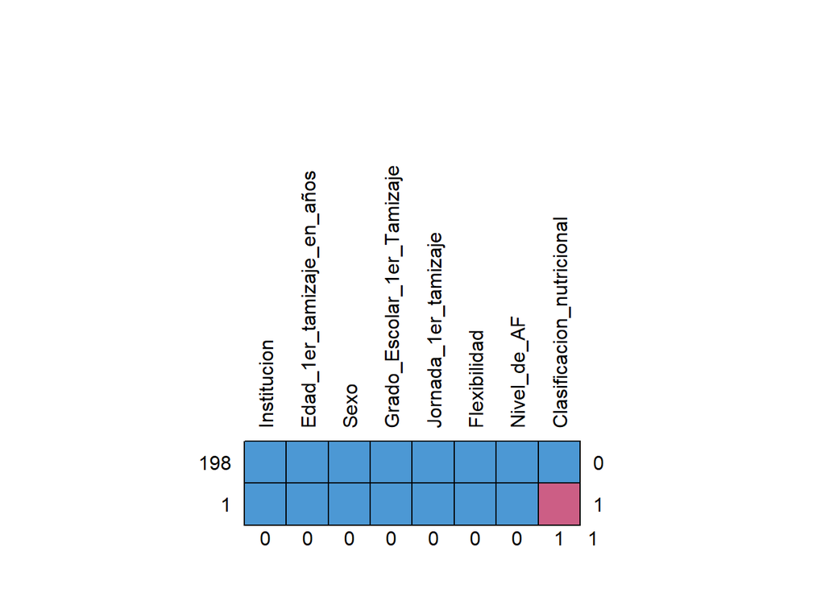

Podemos notar que hay datos faltantes, como es menos del $1\%$, usaremos tecnicas de para la imputacion de datos. Para las variables categóricas usaremos la moda y para las variables numéricas usaremos el promedio

Valores faltantes antes y después de la imputación

| Variable | Antes | Después |
| --- | --- | --- |
| Clasificacion_nutricional | 1 | 0 |

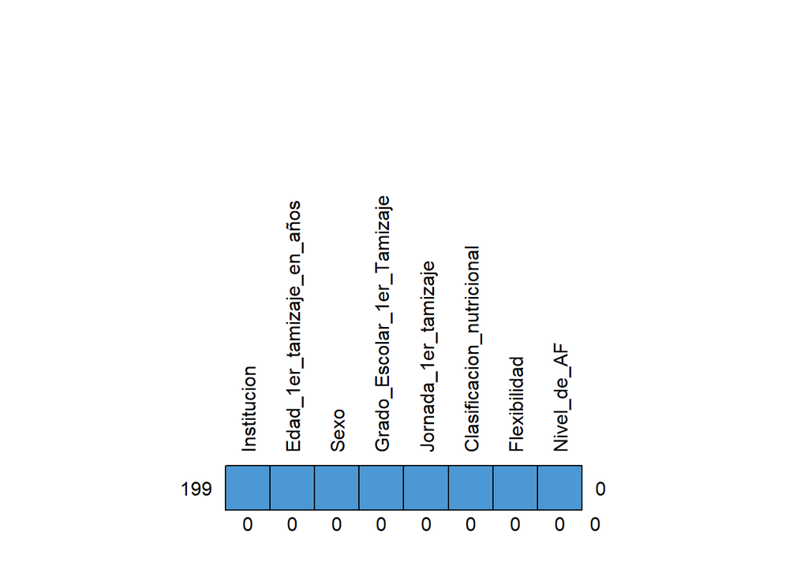

## Caracterización demográfica de los niños

En la Table 1 se presentan las distribuciones correspondientes a las variables categóricas consideradas en el estudio

Table 1: Características sociodemográficas de la muestra

| Variable | Categoria | N (%) |
| --- | --- | --- |
| Institución | MARIE POUSSEPIN | 109 (54.8%) |
| Institución | SANTUARIO | 90 (45.2%) |
| Sexo | F | 151 (75.9%) |
| Sexo | M | 48 (24.1%) |
| Grado Escolar | Primero | 65 (32.7%) |
| Grado Escolar | Quinto | 109 (54.8%) |
| Grado Escolar | Segundo | 25 (12.6%) |
| Jornada | Tarde | 199 (100.0%) |

La muestra total estuvo conformada por 199 participantes. Se observa un equilibrio aceptable entre las dos instituciones participantes, con una leve mayoría del colegio MARIE POUSSEPIN (54.8%) respecto a SANTUARIO (45.2%).

En cuanto a la variable sexo, se evidencia una marcada asimetría a favor del sexo femenino, que representa casi tres cuartas partes de la muestra (75.9%), mientras que el masculino apenas alcanza el 24.1%.

Respecto al grado escolar, la categoría Quinto concentra la mayor proporción (54.8%), seguida por Primero (32.7%), mientras que Segundo presenta una participación marginal (12.6%).

Finalmente, la variable jornada es constante (100% turno tarde), lo que implica que no existe variabilidad intra-muestral en este factor.

En la Tabla Table 2 se presentan las medidas de tendencia central, dispersión y posición para la variable Edad del primer tamizaje, expresada en años cumplidos.

Table 2: Medidas de tendencia central, dispersión y posición para la edad al primer tamizaje (años cumplidos)

| Variable | N | Media | DE | Mediana | Min | Max | Q1 | Q3 |
| --- | --- | --- | --- | --- | --- | --- | --- | --- |
| Edad (años) | 199 | 8.61 | 2.1 | 9 | 5 | 12 | 7 | 10 |

## Caraterización de las variables clínicas

Table 3: Características clínicas de la muestra

| Variable | Categoria | N (%) |
| --- | --- | --- |
| Clasificación Nutricional | Delgadez | 22 (11.1%) |
| Clasificación Nutricional | Adecuado | 110 (55.3%) |
| Clasificación Nutricional | Sobrepeso | 46 (23.1%) |
| Clasificación Nutricional | Obesidad | 21 (10.6%) |

La tabla Table 3 nos muestra el estado nutriciona donde más de la mitad de los escolares evaluados presentó una clasificación adecuada (55,3 %; n = 110). No obstante, se identificó una proporción considerable de escolares con exceso de peso, el sobrepeso constituyó la categoría más frecuente dentro de este grupo (23,1 %; n = 46), seguido de la obesidad (10,6 %; n = 21). La delgadez, por su parte, se presentó en el 11,1 % (n = 22) de los participantes. En conjunto, estos hallazgos evidencian la coexistencia de déficit y exceso de peso, fenómeno descrito en la literatura como doble carga nutricional, en la población escolar estudiada, lo que subraya la necesidad de intervenciones de salud pública que aborden simultáneamente ambos extremos del espectro nutricional.

## Caracterización del nivel de actividad física y flexibilidad de los escolares

En la Tabla Table 4 se presentan los niveles de actividad física y flexibilidad de los escolares evaluados.

Table 4: Nivel de actividad física y flexibilidad de los escolares

| Variable | Categoria | N (%) |
| --- | --- | --- |
| Nivel de Actividad Física | Bajo | 66 (33.2%) |
| Nivel de Actividad Física | Moderado | 91 (45.7%) |
| Nivel de Actividad Física | Alto | 42 (21.1%) |
| Flexibilidad | Muy baja | 37 (18.6%) |
| Flexibilidad | Baja | 133 (66.8%) |
| Flexibilidad | Promedio | 29 (14.6%) |

## Nivel de actividad física según el estado nutricional

Realicemos las pruebas de asociación de la actividad física con respecto a la clasificación nutricional

Table 5: Nivel de actividad física según estado nutricional (chi-cuadrado)

| Estado Nutricional | Bajo | Moderado | Alto | χ² (p-valor) |
| --- | --- | --- | --- | --- |
| Delgadez | 8 (36.4%) | 9 (40.9%) | 5 (22.7%) | 4.665 (p = 0.587) |
| Adecuado | 34 (30.9%) | 57 (51.8%) | 19 (17.3%) |  |
| Sobrepeso | 17 (37.0%) | 16 (34.8%) | 13 (28.3%) |  |
| Obesidad | 7 (33.3%) | 9 (42.9%) | 5 (23.8%) |  |

En la Tabla Table 5 se presenta la distribución del nivel de actividad física según el estado nutricional de los escolares evaluados. No se encontró asociación estadísticamente significativa entre el estado nutricional y el nivel de actividad física ($\chi^2_{(gl=6)} = 4,665$; $p = 0,587$). Tambien, en la mayoría de las categorías nutricionales predominó el nivel moderado de actividad física, con proporciones que oscilaron entre el 34,8 % (sobrepeso) y el 51,8 % (estado nutricional adecuado); la excepción fue la categoría de sobrepeso, donde el nivel bajo de actividad física fue ligeramente más frecuente (37,0 %) que el moderado (34,8 %).

## Nivel de flexibilidad según el estado nutricional

Realicemos las pruebas de asociación de la flexibilidad con respecto a la clasificación nutricional

Table 6: Nivel de flexibilidad según estado nutricional (chi-cuadrado con simulación de 2000 replicas)

| Estado Nutricional | Muy baja | Baja | Promedio | χ² (p-valor) |
| --- | --- | --- | --- | --- |
| Delgadez | 4 (18.2%) | 16 (72.7%) | 2 (9.1%) | 11.395 (p = 0.082, simulado B = 2000) |
| Adecuado | 15 (13.6%) | 72 (65.5%) | 23 (20.9%) |  |
| Sobrepeso | 12 (26.1%) | 32 (69.6%) | 2 (4.3%) |  |
| Obesidad | 6 (28.6%) | 13 (61.9%) | 2 (9.5%) |  |

En la Tabla Table 6 se presenta la distribución del nivel de flexibilidad según el estado nutricional de los escolares evaluados. El análisis mediante Chi-cuadrado con simulación de Monte Carlo (2000 réplicas) no evidenció una asociación estadísticamente significativa entre el estado nutricional y el nivel de flexibilidad ($\chi^2 = 11,395$; $p = 0,082$).

En todas las categorías nutricionales predominó la flexibilidad baja, con proporciones que oscilaron entre el 61,9 % en escolares con obesidad y el 72,7 % en aquellos con delgadez. Al observar las categorías extremas, la flexibilidad muy baja fue más frecuente en escolares con obesidad (28,6 %) y sobrepeso (26,1 %) que en aquellos con estado nutricional adecuado (13,6 %), lo que sugiere una posible tendencia —aunque no estadísticamente significativa— hacia una menor flexibilidad en escolares con exceso de peso. Por su parte, la categoría promedio fue más frecuente en escolares con estado nutricional adecuado (20,9 %) que en los grupos con exceso de peso (4,3 % en sobrepeso y 9,5 % en obesidad).

Si bien estos resultados descriptivos apuntan a un posible gradiente entre el exceso de peso y una menor flexibilidad, la ausencia de significancia estadística ($p = 0,082$) no permite concluir una asociación formal entre ambas variables en esta muestra, lo cual podría deberse al tamaño reducido de algunas subcategorías (p. ej., escolares con delgadez u obesidad). Se sugiere explorar esta tendencia en estudios con muestras de mayor tamaño que permitan una potencia estadística adecuada para detectar asociaciones de esta magnitud.

## Modelo de regresión logística ordinal

Realicemos un modelo de regresión logística ordinal, esto con el fin de ver las variables asociadas y los factores de riesgo y protector

```
[1] 199
```

Table 7: Modelo de regresión logística ordinal (Odds proporcional)

|  | Variable | OR (IC 95%) | p-valor | Interpretación |
| --- | --- | --- | --- | --- |
| SexoM | SexoM | 0.577 (0.258 – 1.291) | 0.181 | No significativo |
| Grado_Escolar_1er_TamizajeQuinto | Grado_Escolar_1er_TamizajeQuinto | 1.023 (0.493 – 2.122) | 0.951 | No significativo |
| Grado_Escolar_1er_TamizajeSegundo | Grado_Escolar_1er_TamizajeSegundo | 0.946 (0.366 – 2.442) | 0.909 | No significativo |
| FlexibilidadMuy baja | FlexibilidadMuy baja | 1.688 (0.825 – 3.451) | 0.151 | No significativo |
| FlexibilidadPromedio | FlexibilidadPromedio | 0.687 (0.302 – 1.563) | 0.371 | No significativo |
| Nivel_de_AFBajo | Nivel_de_AFBajo | 0.725 (0.343 – 1.534) | 0.4 | No significativo |
| Nivel_de_AFModerado | Nivel_de_AFModerado | 0.669 (0.33 – 1.357) | 0.265 | No significativo |

Nota: Modelo: Regresión logística ordinal (Proportional Odds). Categoría de referencia (nivel más bajo del outcome): Delgadez. N = 199 escolares con edad > 4 años. OR > 1 = factor de riesgo; OR < 1 = factor protector.

Table 8: Supuesto de proporcionalidad de odds

| Variable | Chi² | gl | p-valor |
| --- | --- | --- | --- |
| Omnibus | 13.709 | 14 | 0.472 |
| SexoM | 2.244 | 2 | 0.326 |
| Grado_Escolar_1er_TamizajeQuinto | 0.132 | 2 | 0.936 |
| Grado_Escolar_1er_TamizajeSegundo | 0.555 | 2 | 0.758 |
| FlexibilidadMuy baja | 0.559 | 2 | 0.756 |
| FlexibilidadPromedio | 5.113 | 2 | 0.078 |
| Nivel_de_AFBajo | 0.482 | 2 | 0.786 |
| Nivel_de_AFModerado | 2.614 | 2 | 0.271 |

Nota: H₀: se cumple el supuesto de proporcionalidad de odds. p < 0,05 indica violación del supuesto. La fila Omnibus evalúa el supuesto globalmente para todo el modelo; las filas en rojo (si las hay) indican variables individuales que violan el supuesto.

Los resultados del test de Brant permitieron evaluar el supuesto de proporcionalidad de odds, requisito fundamental para la validez del modelo de regresión logística ordinal. A nivel global, la prueba omnibus no rechazó el supuesto de proporcionalidad ($\chi^2_{(gl=14)} = 13,709$; $p = 0,472$), lo que indica que el modelo de odds proporcionales resulta adecuado para los datos analizados (ver Table 8).

A nivel individual, la totalidad de las variables incluidas en el modelo cumplieron el supuesto de proporcionalidad de odds (p > 0,05 en todos los casos), incluyendo sexo, grado escolar, nivel de actividad física y flexibilidad. Si bien la categoría de flexibilidad promedio presentó el valor de p más bajo entre las variables evaluadas ($\chi^2_{(gl=2)} = 5,113$; $p = 0,078$), este no alcanzó el umbral convencional de significancia estadística, por lo que no se considera evidencia de violación del supuesto. En conjunto, estos resultados respaldan el uso del modelo de odds proporcionales como estrategia analítica principal, confirmando que los OR reportados pueden interpretarse de manera consistente a través de las categorías del estado nutricional (ver Table 8).